# Tutorial 4: Probability Distributions

NAT

today

Welcome to the course repository. Below you will find the links to the slide decks and tutorial materials.

| Materials | Tutorials | Solution |
| --- | --- | --- |
| Statistical Book |  |  |
| Slide 1: Probability Basics (Part 1) | Tutorial 1 | Solution 1 |
| Slide 2: Probability Basics (Part 2) | Tutorial 2 | Solution 2 |
| Slide 3: Random Variables, Expectation, and Moments | Tutorial 3 | Solution 3 |
| Slide 4: Probability Basics | Tutorial 4 | Solution 4 |
| **Full Course Compilation** |  |  |

### Complete Course Notes

- Open the Full Course Notes

*Note: Clicking a slide link will open the HTML presentation. To save the slides as a PDF, open the HTML presentation in your web browser and use the browser’s “Print to PDF” function.*

### Extra Materials

1. Random Walk
2. Monty Hall

## Basic Concepts of Statistics & Random Experiments

- Statistics involves collecting, classifying, summarizing, organizing, analyzing, and interpreting data
- A random experiment is an experiment where the outcome cannot be predicted with certainty.
- **Defining Characteristics of a Random Experiment:**
  1. All possible outcomes of the experiment are known in advance.
  2. Any single performance of the experiment results in an outcome that is not known in advance.
  3. The experiment can be repeated under identical conditions.

## Definition of a Set & Membership

- **Definition** A set is simply a collection of objects, these objects being called elements or members of the set.
- Examples include the set of all real numbers and the set of all UPNM students
- Membership of a set $X$ by an object $x$ is denoted by a special symbol $\in$, read as “belongs to”
- The statement $x \in X$ means that $x$ is an element of, or belongs to, $X$ .
- There is also an opposite statement $x \notin X$ which means that $x$ is not an element of, or does not belong to, $X$ .
- **Example:** For example, with $S$ being the set of all students registered for TPQ3783,  
  $\in S$ (enter your name)

## Specifying sets

- Example of a set

  $$\begin{align}
  S:= \{1, 2, 3, 4, 5, 6\}
  \end{align}$$
  - The notation “:= ” means “is defined to be equal to
  - $S$ is a set that contains exactly six numbers listed
  - The order of the elements does not matter. Its membership/ existance in the set is important
  - If the set is large (multiple/ many members/ elements) **and** have a clear pattern, $\ldots$ is typically used. E.g.: $S:= \{1, \ldots, 20\}$

## Definition and Properties of Probability

- Probability is a real-valued set function $P$ that assigns a number $P(A)$ to each event $A$ in the sample space $S$.
- $P(A) \ge 0$
- $P(S) = 1$
- If $A_1, A_2, \dots$ are mutually exclusive events ($A_i \cap A_j = \emptyset$ for $i \neq j$), then $P(A_1 \cup A_2 \cup \dots) = P(A_1) + P(A_2) + \dots$
- $P(\emptyset) = 0$ and $0 \le P(A) \le 1$
- $P(A') = 1 - P(A)$
- $P(B \cap A') = P(B) - P(B \cap A)$
- $P(A \cup B) = P(A) + P(B) - P(A \cap B)$
- If $A \subset B$, then $P(A) \le P(B)$

## Examples of Random Experiments

- **The experiment of tossing a coin:**
  - There are two possible outcomes: getting a Head (H) or getting a Tail (T).
  - Even though we know both **possible outcomes**, we cannot definitively predict that we will get a tail if we throw the coin in a particular manner.
- **The experiment of rolling a die:**
  - There are six possible outcomes: the die showing up 1, 2, 3, 4, 5, or 6.
  - We cannot for sure predict that we can make a particular number appear on the face of the dice when it is rolled.

## Applied Real-Life Examples

- **Quality Control & Manufacturing:**
  - Testing the length of life of a 60-watt light bulb until it burns out.
    - There infinitely number of possible of outcomes. (Why?)
- **Environmental Testing:**
  - Counting the number of bacteria colonies in a 100-milliliter water sample taken from a specific lake basin.
- **Technology Reliability:**
  - Measuring the continuous amount of time in hours that a computer functions before breaking down.
- **Queueing & Logistics:**
  - Measuring the waiting time in minutes until the first customer or patient arrives at a facility.

## Properties of Probability

- Sample Space, $S$
- The event set, $E$
- The probability measure, $p$

### Properties of Probability: Examples

- **The experiment of tossing a coin:**
  - Sample Space, $S:= \{H, T \}$
  - Event set of getting a Head, $E:= \{H \}$
  - Probability measure of $E$: $p = \frac{1}{2}$

| Probability measure | Description |
| --- | --- |
| $P(A) \ge 0$ | Probabibility of an event $A$ is $0$ or greater |
| $P(S) = 1$ | Probability of space $S$ is 1 |
| $0 \le P(A) \le 1$ | Probability is always between $0$ and $1$. |

## Review of Set Algebra

| Symbols | Description |
| --- | --- |
| $\emptyset$ | The null set or empty set. |
| $A \subset B$ | $A$ is a subset of $B$. |
| $A \cup B$ | the union of $A$ and $B$, representing elements in either set. |
| $A \cap B$ | The intersection of $A$ and $B$, representing elements shared by both sets. |
| $A'$ | The complement of $A$, representing everything outside of $A$. |
| **Mutually Exclusive:** | Events $A_1, A_2, \dots, A_k$ are mutually exclusive if $A_i \cap A_j = \emptyset$ for $i \neq j$; they are disjoint sets. |
| **Exhaustive Events:** | Events $A_1, A_2, \dots, A_k$ are exhaustive if their union forms the entire sample space, $A_1 \cup A_2 \cup \dots \cup A_k = S$. |

- So if $A_1, A_2, \dots, A_k$ are mutually exclusive and exhaustive events, we know that $A_1 \cap A_2=\emptyset$, for $i \ne j$ and $A_1 \cup A_2 \cup \dots \cup A_k = S$

## Properties of Set Operations

- **Commutative Laws:** The order of the sets can be swap
  - $A \cup B = B \cup A$.
  - $A \cap B = B \cap A$.
- **Associative Laws:** The groups can be changed. It allows for the removal of brackets
  - $A \cup B \cup C = A \cup (B \cup C)$.
  - $A \cap B \cap C = A \cap (B \cap C)$.
- **Distributive Laws:** Multiplication across addition/ substraction
  - $A \cap (B \cup C) = (A \cap B) \cup (A \cap C)$.
  - $A \cup (B \cap C) = (A \cup B) \cap (A \cup C)$.
- **De Morgan’s Laws:**
  - $(A \cup B)' = A' \cap B'$.
  - $(A \cap B)' = A' \cup B'$.

## Additional Properties of Probability

- Probability is a real-valued set function $P$ that assigns a number $P(A)$ to each event $A$ in the sample space $S$.

| Properties of probability | Description |
| --- | --- |
| $P(A) \ge 0$ | Probabibility of an event $A$ is $0$ or greater. |
| $P(S) = 1$ | Probability of space $S$ is 1. |
| $P(\emptyset) = 0$ | Probability of an empty set $\emptyset$ is $0$. |
| $0 \le P(A) \le 1$ | Probability is always between $0$ and $1$. |
| $P(A') = 1 - P(A)$ | Given event $A$. The probability of the complement of event $A$, i.e. $A^{c}$ or $A$’ is $1 - P(A)$ |
| $P(A) = \sum_{i = 1}^{\infty} P(A \cap B_{i})$ | Law of Total probability |
| $P(A) \le P(B)$ | If $A \subset B$, then $P(A) \le P(B)$ |
| $P(B \cap A)$ | Probability that elements exists in both events $A$ and $B$ |
| $P(B \cap A') = P(B) - P(B \cap A)$ |  |
| $P(A \cup B) = P(A) + P(B) - P(A \cap B)$ |  |
| $P(A_1 \cup A_2 \cup \dots) = P(A_1) + P(A_2) + \dots$ | If $A_1, A_2, \dots$ are mutually exclusive events ($A_i \cap A_j = \emptyset$ for $i \neq j$), then $P(A_1 \cup A_2 \cup \dots) = P(A_1) + P(A_2) + \dots$. |

## Probability Calculation Example

- **Experiment:** Tossing a coin twice.
- **Sample Space:** $S := \{HH, HT, TH, TT\}$, where each outcome is equally likely with a probability of $1/4$. (Hint: *equally likely*: each elements in the set of equal chance of being selected hence each element has the probability of 1/4)
  - Let $E := \{HH, HT\}$ be the event that the first toss is a head.
  - Let $F := \{HH, TH\}$ be the event that the second toss is a head.

  Find the probability of the union $P(E \cup F)$:

  **Answer** (step-by-step):
  1. $P(E \cup F) = P(E) + P(F) - P(E \cap F)$.
  2. $P(E \cup F) = 1/2 + 1/2 - P(\{HH\})$.
  3. $P(E \cup F) = 1 - 1/4 = 3/4$.
  4. Alternatively, $P(E \cup F) = P(\{HH, HT, TH\}) = 3/4$.

## Probability Calculation Example

- **Experiment:** Tossing a fair dice.
- **Sample Space:** $S := \{1, 2, 3, 4, 5, 6\}$ where each outcome is equally likely
  - Let $E$ be the event that consist of event numbers
  - Let $F$ be the event that consist of numbers greater than 3

  Find the probability of the union $P(E \cup F)$:

## Probability Calculation: In-class exercise (A practice to your quiz)

**Task:** To answer the following questions, you will need to pair up with a friend.

1. You are given 10 minutes. Try to answer the following questions.
2. After 10 minutes, switch your answer with your friend. 5 minutes, review your friends work and add any missing steps/ fix the calculation if needed.
1. If $P(A) = 0.4$, $P(B) = 0.5$ and $P(A \cap B) = 0.3$, calculate the following:
1. $P(A \cup B)$
2. $P(A \cap B')$
3. $P(A' \cup B)$

- $P(A_{i}) = \frac{1}{3}$ for $i = 1, 2, 3$
- $P(A_{i} \cap A_{j}) = \left(\frac{1}{3}\right)^{2}$ for $i \ne j$ and $P(A_{1} \cap A_{2} \cap A_{3}) = \left(\frac{1}{3}\right)^{3}$.

Find $P(A_1 \cup A_2 \cup A_3)$.

[4 mark]

## Method of Enumeration & Multiplication Principle

- The method of enumeration is used to determine the **number of outcomes associated with the events of certain random experiments**.
- **Multiplication Principle:** If an experiment $E_1$ has $n_1$ outcomes and for each possible outcome, a second experiment $E_2$ has $n_2$ possible outcomes, the composite experiment $E_1 E_2$ has $n_1 n_2$ possible outcomes.
- **Example:** Tossing a coin ($E_1$ with 2 outcomes) and rolling a die ($E_2$ with 6 outcomes).
  - The total number of outcomes is $2 \times 6 = 12$.
  - The sample space represented in ordered pairs: $S = \{(H,1), (H,2), (H,3), (H,4), (H,5), (H,6), (T,1), (T,2), (T,3), (T,4), (T,5), (T,6)\}$.
- If an experiment is repeated multiple times, such as tossing a coin ten times, the number of outcomes in the sample space is $2 \times 2 \times \dots \times 2 = 2^{10}$.

## Probability Distribution

- Experiment involves arrangement, selection and replacement.
- Suppose that we have 4 letter a,b,c and d, the number of possible four-letter code easily can be calculated if each letter can be repeated which is $4^4=256$
- If consider without repetition, then the number of possible four-letter code is the number of permutation of 4 letter which is $4!=24.$

## Permutations and Combinations (Sampling)

- **Arrangement and Replacement Example:** Given 4 letters a, b, c, and d.
  - With repetition: The number of possible four-letter codes is $4^4 = 256$.
  - Without repetition: The number of possible four-letter codes is a permutation of 4 letters, which is $4! = 24$.
- **Case 1 (Replacement, Ordered):** Sampling with replacement of an ordered sample of size $r$ yields $n^r$ arrangements, i.e. $r = n^r$.
- **Case 2 (No Replacement, Ordered - Permutation):** Sampling without replacement of $r$ ordered items from $n$ objects.
  - $_nP_r = \frac{n!}{(n-r)!}$. It must be true that $r \le n$.
- **Case 3 (No Replacement, Unordered - Combination):** Sampling without replacement of $r$ selected objects from $n$ objects with unordered subsets.
  - $_nC_r = \frac{n!}{r!(n-r)!}$.

## Permutation Calculation Example

1. Suppose that two tennis players A and B are playing in a match. The first player that wins three sets will win the match. How many ways could this tennis match ends?

## CLO

1. CLO 1: APPLY the concept of probability in relation to the concept of sampling error. (C3)
2. CLO 2: EXPLAIN the concept of point and confidence interval estimation for given parameters. (C2, A4)
3. CLO 3: DESIGN appropriate hypothesis testing based on given statistical problems. (C5, P7)

## Objectives

1. Recall sets and intervals
2. Calculate probability of events
3. Calculate probability of intersection and conditional probability
4. Introduction to Bayes’s rule

## Recall:

- A set is simply a collection of objects, these objects being called elements or members of the set.
- $A \subseteq B$: If every element of $A$ is also an element of $B$ ($A$ included in $B$)
- $A \subset B$ ($A \subset B$): $A$ is a proper subset of $B$ if it is a subset of $B$ and there is at least one element of $B$ that is not in $A$.
- Standard sets of numbers: $\mathbb{N}, \mathbb{Z}, \mathbb{N}_{0}, \mathbb{Q}, \mathbb{R}, \mathbb{C}$

$$\mathbb{N} \subseteq \mathbb{N}_{0}
\subseteq \mathbb{Z} \subseteq \mathbb{Q} \subseteq \mathbb{R} \subseteq
\mathbb{C}$$
- Sets are mathematical objects and we can have set of sets:

$$S:= \{1, 2\}$$
The set is: $\{\emptyset, \{1\}, \{2\}, \{1,2\}\}$

## Intervals

- Consider two numbers, $a, b \in \mathbb{R}$
- The open interval is: $(a, b):= \{x \in \mathbb{R}: a < x < b \}$
- The close interval is: $[a, b]:= \{x \in \mathbb{R}: a \le x \le b \}$
- The open and close interval: $(a, b]:= \{x \in \mathbb{R}: a < x \le b \}$
- The close and open interval: $[a, b):= \{x \in \mathbb{R}: a \le x < b \}$
- Unbounded intervals: $[a, \infty):= \{x \in \mathbb{R}: a \le x \}$
- Unbounded intervals: $(-\infty, b]:= \{x \in \mathbb{R}: x \le b \}$

## Probability of an event

- Probability of any event, $A$, as the proportion of the possible outcomes which give rise to that event

$$\begin{align}
\frac{\text{no. of possible outcomes which give rise to
event}}{\text{total no. of possible outcomes}}
\end{align}$$

## Probability of an event: Equally likely outcomes

**The Leibniz-Galileo Problem**

In a game of tossing three fair dice, Leibniz thought that probability of getting a total is 10 and the probability that the total is 9 are equals. However, Galileo thought that these two probabilities are in the ratio 27:25.

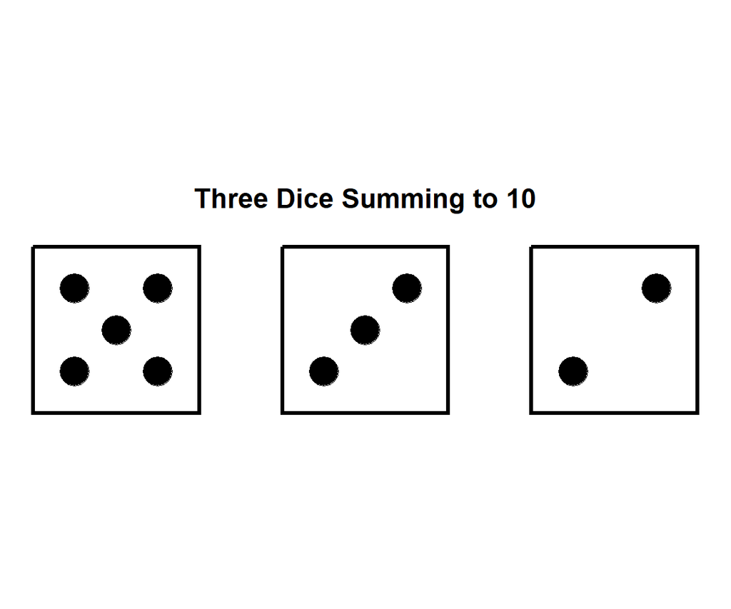

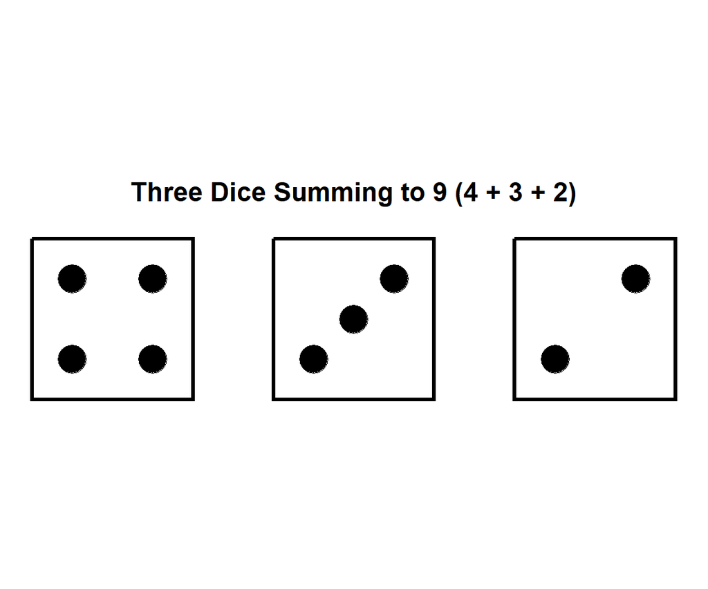

## Probability of an event: Frequency interpretation of probability

If an ``experiment” can be repeated indefinitely, then the relative frequency of any event at any stage is defined as

$$\begin{align}
\frac{\text{no. of occurrences of event so far}}{\text{total no. of
repetitions of experiment so far}}
\end{align}$$

- This relative frequency will obviously fluctuate randomly as the number of repetitions increases, but the expectation is that it will in the long run settle down to a limiting value which is the probability of the event.
- This method is to find the probabilities to events in cases where there is no symmetry

## Probability of an event: Example

A batch of 15 items contains 6 defective ones. A random sample of 5 is chosen. What is the probability that 2 are defective?

**Answer (Step-by-step)**

1. Total no.of possible outcomes is how many ways that 5 defective items is chosen.

${15 \choose 5} =$

2. No. of possible outcomes which give rise to event

${6 \choose 2}=$

3. Probability of event $A$: $P(A)$

## Probability of an event: Example

A batch of 15 items contains 6 defective ones. A random sample of 5 is chosen. What is the probability that **at least** 2 are defective?

**Answer (Step-by-step)**

1. Total no.of possible outcomes is how many ways that 5 defective items is chosen.

${15 \choose 5} =$

2. No. of possible outcomes which give rise to event

${6 \choose 2}=$

## Probability of an event: Classical vs Uniform Measures

- Recall the clasical measure:
- E.g.: Let $S:= \{s_1, s_2, \ldots, s_k\}$. For any events $A \subset S$,

$$\begin{align}
\frac{\text{no. of possible outcomes in $A$}}{\text{total no. of
possible outcomes in $S$}}
\end{align}$$

- If $A:= \{s_i\}$, then $P(A) =$
- For constinuous $S$, we use **uniform** measure
  - if $S$ is two-dimensional and of finite area then we define
    $$P(A) =
    \frac{\text{area of $A$}}{{\text{area of $S$}}}$$
- Note:
  - When an outcome is chosen at random from a sample space $S$: classical probability measure is used
  - When $S$ is discrete, and the uniform measure if $S$ is continuous.
  - For continuous probability measures, events of probability $0$ are NOT impossible and events of probability $1$ are NOT certain.

## Probability of an event: Classical vs Uniform Measures: Example

The diagram below shows a rectangle with a length of 8 and a width of 4. It is divided into four triangular regions by drawing the two diagonal lines from corner to corner. The regions are numbered from 1 to 4:

- Region 1 is the top triangle,
- Region 2 is the right triangle,
- Region 3 is the bottom triangle, and
- Region 4 is the left triangle.

## Probability of an event: Classical vs Uniform Measures: Example (continue)

The perimeter is divided into 4 edges numbered in accordance with the regions (Edge 1 is the top edge, Edge 2 is the right edge, etc.).

1. A **point** is chosen at random from the **rectangle**. What is the probability that it is **in** region 1? What is the probability that it is **in** region 2?
2. A **point** is chosen at random from the **perimeter of the rectangle**. What is the probability that it is **on** edge 1? What is the probability that it is **on** edge 2?

## Probability of an event: Classical vs Uniform Measures: Example

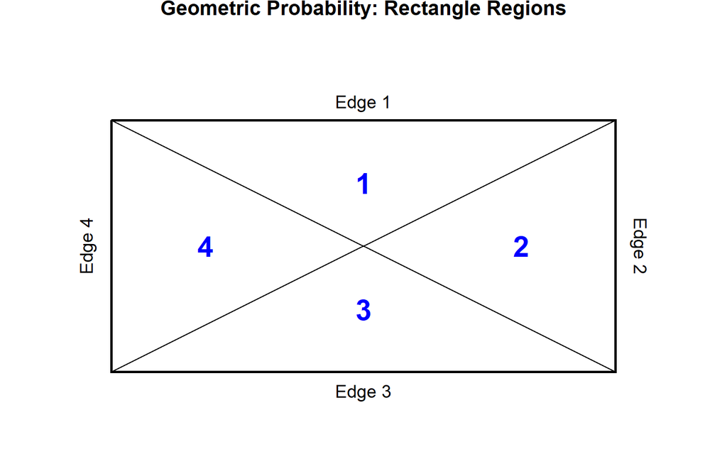

## Probability of an event: Classical vs Uniform Measures: Example

- Consider the experiment where one point is chosen at random from the interval $[0, 1]$. For $a \in [0, 1]$, $P(a) = 0$, that is, the event $x = a$ has probability $0$, in the uniform probability measure.
  - Points have zero length.
  - But that does not mean that this event is impossible:
  - if we choose a point at random from $[0, 1]$ then any point could be chosen but the probability that a particular point is chosen is 0.
- To get a positive probability, we need an event:
  - E.g.: $\frac{1}{4} \le a \le \frac{3}{4}$ where the probability is $\frac{1}{2}$

## Independent vs. Dependent Events

- **Problem Context:** Consider selecting 2 cards from a standard deck of 52 cards.
  - *With replacement:* The probability of obtaining two kings involves **independent events**.
  - *Without replacement:* The probability of obtaining two kings involves **dependent events**.

## Independent vs. Dependent Events

- **Independent Events:** Two events are independent if the occurrence of one of the events does not affect the probability of the occurrence of the other event.

$$\begin{align}
P(A \cap B) = P(A) P(B)
\end{align}$$

- For more then two finite events, a set of *mutually exclusive* events are

$$\begin{align}
P(A_1 \cap A_2 \cap \ldots A_k) = P(A_1) P(A_2) \ldots P(A_k)
\end{align}$$

## Independent vs. Dependent Events

- **Dependent Events:** Two events are dependent if the occurrence of one of the events affects the probability of the occurrence of the other event.
- Problems with dependent events can often be solved using conditional probability, also known as the multiplication rule.
- Events that are not independent are dependent.
- Event $A$ and $B$ are **independent** iff $P(A \cap B) = P(A \cap B) = P(A) P(B)$. Otherwise, $A$ and $B$ are **dependent**
- Dependent events can be solved using tree diagaram

## Independent Events: Example

Let $A$ and $B$ be independent events with $P(A) = 0.7$ and $P(B) = 0.2$. Compute

1. $P(A \cap B)$

Since $A$ and $B$ are independent,
$$\begin{align}
P(A \cap B) = P(A) P(B) = 0.7 \times 0.2 = 0.14
\end{align}$$

2. $P(A \cup B)$

$$\begin{align}
P(A \cup B) = P(A) + P(B) - P(A \cap B) = 0.7 + 0.2 -0.14 = 0.76
\end{align}$$

3. $P(A' \cup B')$

Using De Morgan’s second law,

## Independent Events: Example

Toss a fair coin twice. Let $A$ be the event “head on first toss”, $B$ be the event “head on second toss” and $C$ be the event “same face on both tosses”. Show that these three events are pairwise independent but not mutually independent.

Solution:

## Independence: Example

Toss a fair coin twice. Let

- $A$ be the event head on first toss,
- $B$ be the event head on second toss
- $C$ be the event “same face on both tosses”.

Show that these three events are pairwise independent but not mutually independent.

## Independent Events: Exercise

If $P(A) = 0.8$, $P(B) = 0.5$, and $P(A \cup B) = 0.9$, are $A$ and $B$ independent events? Show your answer.

## Independent Events: Exercise

Let $A$ be the event that the sum of the two numbers shown is $7$, let $B$ be the event that the sum of the two numbers shown is 8 and $C$ be the event that the first number shown is even.

1. Find the probabilities of the events $A, B, C$, $A \cap C$ and $B \cap C$.
2. Are $A$ and $C$ independent? Are $B$ and $C$ independent?
3. Justify your answers.

## Independent Events vs. Dependent Events: Examples

**Independent Events**

- Flipping a coin and rolling a die: Getting “Heads” on the coin doesn’t change your 1-in-6 chance of rolling a “4” on the die.
- Buying a lottery ticket and getting a flat tire: Winning (or losing) the lottery has no influence on the probability of your tire popping on the way home.
- Having a boy, then having another boy: The biological odds of having a boy are roughly 50%. Having a boy first does not magically make the odds of having a girl next time 100%. The odds reset to 50% for the second child.
- When training a model to recognize tumors in MRI scans, Patient A’s scan is completely independent of Patient B’s scan. The outcome of one does not change the probability of the other. If you shuffle the order of the images during training, the model learns exactly the same way.
- This classification algorithm (often used for spam filtering) calculates probabilities by making a “naive” assumption: it treats every feature as an independent event. It assumes the presence of the word “urgent” in an email is completely independent of the presence of the word “money,” multiplying their individual probabilities together to guess if the email is spam.

## Independent Events vs. Dependent Events: Examples

**Dependent Events**

- If you draw an Ace from a standard 52-card deck and keep it in your hand, the odds of drawing another Ace change. There are now only 3 Aces left in a 51-card deck.
- If you have 10 black socks and 10 white socks, the odds of pulling a black sock are 50%. If you pull out a black sock and put it on your foot, there are now only 9 black socks left out of 19. The odds for your second pull have changed.
- If there is a major accident on your route to work (Event A), the probability that you will be late to work (Event B) drastically increases. (Traffic data)
- Text generation relies entirely on dependent probability. If an LLM is generating a sentence and has already output “The quick brown”, the probability of the next word being “fox” is massively higher than it would have been if the previous words were “I ate a”. The next prediction depends directly on the sequence of previous predictions. (Large Language Models (NLP))
- The probability that it will rain on Tuesday is highly dependent on the barometric pressure and weather conditions from Monday. Models like ARIMA or Recurrent Neural Networks (RNNs) are specifically designed to handle this dependency. (Time Series Forecasting)

## Probability Tree Diagram

- Tree diagrams can be used to determine the value of the probability for dependent events.

[interactive chart not shown]

## Conditional Probability

- **Definition 1.3-1:** The conditional probability of an event $A$, given that event $B$ has occurred, is defined mathematically.
- The formula for conditional probability is:

  $$P(A|B) = \frac{P(A \cap
  B)}{P(B)}$$

  provided that $P(B) > 0$.

## Properties of Independent Events

- **Definition:** Events $A$ and $B$ are independent if and only if $P(A \cap B) = P(A)P(B)$. Otherwise, $A$ and $B$ are called dependent events.
- **Properties of Independent Events:**
  - If $A$ and $B$ are independent, then $P(A|B) = P(A)$ if $P(B) > 0$, and $P(B|A) = P(B)$ if $P(A) > 0$.
  - If $A$ and $B$ are independent, so are $A$ and $B'$, $A'$ and $B$, and $A'$ and $B'$.

## Conditional Probability: Example

A bowl contains 8 chips, where 3 of the chips are red and the remaining five are blue. Two chips are to be drawn successively, at random and without replacement. We use conditional probability to find the probability that the first draw results in a red chip ($C_1$) and that the second draw results in a blue chip ($C_2$).

[interactive chart not shown]

1. Calculate the conditional probability that a red chip was drawn in the second step given that the a blue chip was drawn previously.
2. What is the probability of drawing a red chips in the second time?

## The Birthday Problem

*What is the probability that, in a group of n people, two of them share the same birthday?*

*How many people would need to be in a room for there to be a 50 percent chance that at least two of them share the same birthday?*

- **Person 1:** Enters an empty room with 365 out of 365 days available.
- **Person 2:** Given Person 1 claimed a day, they only have 364 safe days left to avoid a match ($P = \frac{364}{365}$).
- **Person 3:** Strictly dependent on the first two outcomes, they only have 363 days left ($P = \frac{363}{365}$).
- **Person 25:** Strictly dependent on the first 24 outcomes, they only have 341 safe days left ($P = \frac{341}{365}$).
- To find the probability of at least one shared birthday, we multiply the conditional probabilities of *avoiding* a match, then use the rule of complements.

$$P(\text{Match}) = 1 -
\left(\frac{365}{365} \times \frac{364}{365} \times \dots \times
\frac{341}{365}\right)$$
$$P(\text{Match}) = 1 - 0.4313 =
0.5687$$

- With **23 people**, the probability crosses 50.7%.
- With **70 people**, the probability hits 99.9%.

## Interactive Game: The Impossible Bet

- **The Setup:** Offer a crowd of 30+ people a $10 bet that a shared birthday exists in the room.
- **The Execution:** Call out months one by one. Have people born in that month stand up and state their day.
- **The Reveal:** The audience falls for the intuitive trap, but the math is heavily in your favor. Statistically, two people standing will call out the same number well before you reach December.

## Conditional Probability: Example

1. When Netflix or Amazon recommends something to you, they are rarely looking at items in a vacuum. They are calculating conditional probabilities based on user behavior.

   E.g.: “What is the probability this user will watch Stranger Things ($Event\ A$), given that they already watched The Umbrella Academy ($Event\ B$)?”
2. A Markov Model is a system that transitions from one state to another, where the probability of the next state depends only on the current state.

   E.g.: “Given that the current word is ‘New’ ($Event\ B$), what is the probability that the next word is ‘York’ ($Event\ A$) versus ‘shoes’?”

## Conditional Probability: Exercise

A velvet bag contains 15 marbles in three different colors (three possible events per draw):

- 6 Red marbles
- 5 Blue marbles
- 4 Green marbles

You draw 4 marbles in a row without putting any back (four dependent steps).

What is the exact probability of drawing a Red, then a Blue, then a Green, and finally another Red marble?

## Conditional Probability: Exercise

An IT specialist is analysing traffic on a highly secure corporate email server. Because the security is very tight, spam is quite rare.

Only 5% of all incoming emails are actually Spam. The other 95% are Legitimate internal emails. You are looking at how often the word “URGENT” is used in these emails.Spammers love this word. If an email is Spam, there is a 40% chance it contains the word “URGENT”. Normal employees rarely use it. If an email is Legitimate, there is only a 2% chance it contains the word “URGENT”.

An alert pops up: A new email has just arrived, and it contains the word “URGENT”.

Based on conditional probability, what is the exact percentage chance that this specific email is actually Spam?

## Bayes’ Theorem

- Let $B_1, B_2, \dots, B_m$ constitute a partition of the sample space $S$.
- This means that $S = B_1 \cup B_2 \cup \dots \cup B_m$ and $B_i \cap B_j = \emptyset$ for $i \neq j$.
- Then for any event $A$ that is a subset of $S$, Bayes’ Theorem is given by:

  $$P(B_k|A) =
  \frac{P(B_k)P(A|B_k)}{\sum_{i=1}^{m} P(B_i)P(A|B_i)}$$

## Bayes’ Theorem:

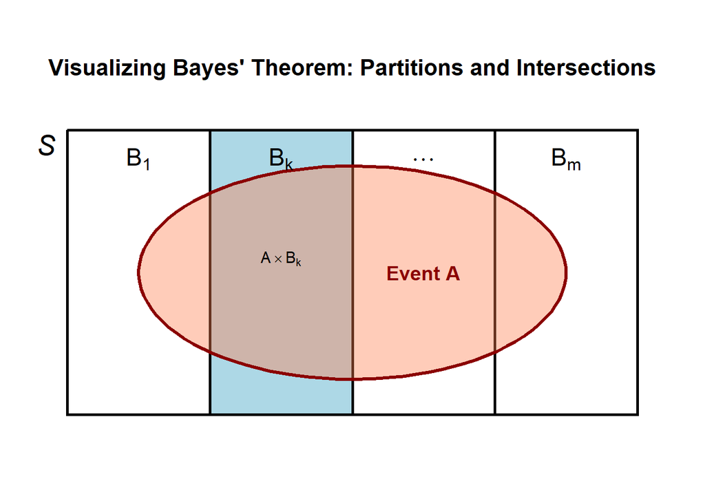

Out of the entire area where Event A happens (the complete coral oval), what exact percentage of that area belongs to our target scenario $B_k$?

- The numerator ($P(B_k)P(A\vert{}B_k)$) is just the area of the specific intersection chunk inside $B_k$.
- The denominator ($\sum_{i=1}^{m} P(B_i)P(A\vert{}B_i)$) is just the total area of the coral oval, calculated by adding up all of its individual chunks across every partition.

## Bayes’ Theorem: Proof

By the definition of conditional probability, the probability of event $B_k$ given event $A$ is:

$$P(B_k|A) = \frac{P(B_k \cap
A)}{P(A)}$$

Using the multiplication rule of probability, we can express the intersection in the numerator as:

$$P(B_k \cap A) =
P(B_k)P(A|B_k)$$

Next, because $B_1, B_2, \dots, B_m$ form a partition of the sample space $S$, we can apply the Law of Total Probability to expand the denominator $P(A)$. The event $A$ can occur in conjunction with any of the mutually exclusive events $B_i$:

$$P(A) = \sum_{i=1}^{m} P(B_i \cap
A)$$

Applying the multiplication rule to each term in the sum gives:

$$P(A) = \sum_{i=1}^{m}
P(B_i)P(A|B_i)$$

Finally, substituting the expanded numerator and the expanded denominator back into the original conditional probability formula yields Bayes’ Theorem:

$$P(B_k|A) =
\frac{P(B_k)P(A|B_k)}{\sum_{i=1}^{m} P(B_i)P(A|B_i)}$$

## Bayes Rule: Example 1

- Sample Space ($S$): The entire population being tested.
- The Partitions ($B_1$ and $B_2$):
  - $B_1$ (Has Disease): $1\%$ of the population actually has the disease.
  - $B_2$ (Healthy): $99\%$ of the population does not have the disease.
- Event $A$ (Positive Test Result): The test comes back Positive.
  - If a patient has the disease ($B_1$), the test is $90\%$ accurate.
  - If a patient is healthy ($B_2$), the test has a $5\%$ false positive rate

## Bayes Rule: Example 2 (Heart Disease (Medical Screening))

- Sample Space ($S$): All patients walking into a clinic.
- Partitions ($B_1$ and $B_2$):
  - $B_1$: Patients who actually have Heart Disease.
  - $B_2$: Patients who are Healthy (No Heart Disease).
- Event $A$ (Chest Pain): A patient presents with chest pain.
  - $A \cap B_1$ (True Positive Indicator): Patients who have heart disease and experience chest pain.
  - $A \cap B_2$ (False Alarm): Healthy patients who experience chest pain due to harmless causes (like acid reflux or muscle strain).

## Bayes’ Theorem Application: Example

At a hospital’s emergency room, patients are classified and 20% of them are critical, 30% are serious, and 50% are stable.

- Of the critical ones, 30% die; of the serious, 10% die; and of the stable, 1% die.
- Given that a patient dies, what is the conditional probability that the patient was classified as critical?

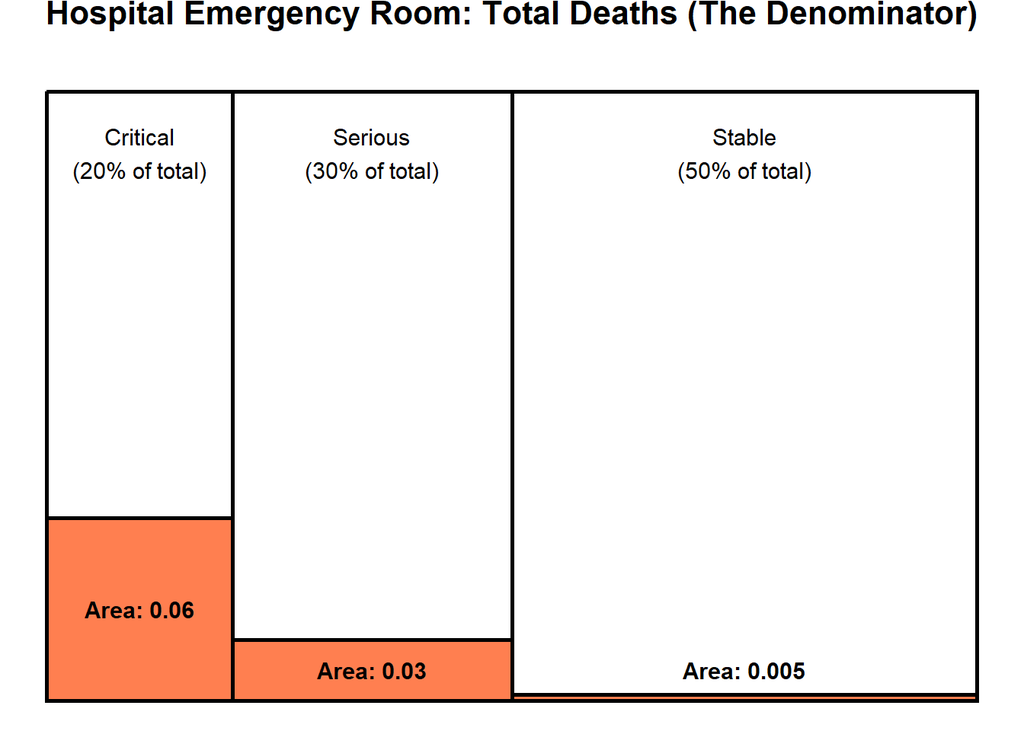

## Bayes’ Theorem Application: Example

You are building a model to detect spam emails. Your historical data shows that exactly 5% of all login attempts on your platform are fraudulent. Consequently, 95% are legitimate.Your model evaluates logins based on three distinct features:

1. $F_1$ (Late Night): The login occurs between 2 AM and 5 AM.
2. $F_2$ (VPN Used): The login IP is routed through a known commercial VPN.
3. $F_3$ (Crypto Purchase): The first action after login is attempting to buy cryptocurrency.

## Bayes’ Theorem Application: Example (continue)

Based on your training data, you have the following conditional probabilities likelihoods) for how often these features appear in both classes:

If a login is Fraudulent:

- $P(\text{Late Night} \vert{} \text{Fraud}) = 60\%$
- $P(\text{VPN} \vert{} \text{Fraud}) = 80\%$
- $P(\text{Crypto} \vert{} \text{Fraud}) = 50\%$

## Bayes’ Theorem Application: Example (continue)

If a login is Legitimate:

- $P(\text{Late Night} \vert{} \text{Legitimate}) = 10\%$
- $P(\text{VPN} \vert{} \text{Legitimate}) = 10\%$
- $P(\text{Crypto} \vert{} \text{Legitimate}) = 20\%$

What is the posterior probability that a login is Fraudulent given that all three features ($F_1$: Late Night, $F_2$: VPN, $F_3$: Crypto Purchase) are present?

## CLO

1. CLO 1: APPLY the concept of probability in relation to the concept of sampling error. (C3)
2. CLO 2: EXPLAIN the concept of point and confidence interval estimation for given parameters. (C2, A4)
3. CLO 3: DESIGN appropriate hypothesis testing based on given statistical problems. (C5, P7)

## Objectives

1. Recall random variables
2. Discrete and continuous random variables
3. Expected valus, variance and standard deviation of random variables
4. Moments and Moment Generating Functions

## Random Variables

- Given a random experiment with an outcome space $S$, a function $X$ that assigns one and only one real number $X(s) = x$ to each element $s$ in $S$ is called a random variable. The space of $X$ is the set of real numbers $\{x: X(s) = x, s \in S\}$.
- A random variable, usually written X, is a variable whose possible values are numerical outcomes of a random phenomenon

## Random Variables: Example

1. For a rat selected at random, the outcome space is $S = \{F, M\}$. If $X(F) = 0$ and $X(M) = 1$, $X$ is a random variable with the space $\{0, 1\}$.
2. When tossing a die, the outcome space is $S = \{1, 2, 3, 4, 5, 6\}$.
   - The experiment is tossing a die. Then the outcome space associated with this experiment is S= {1, 2, 3, 4, 5, 6} with elements of S indicating the number of spots on the side facing up. For each s∈S, let X(s) = s. the space of the random variable X is then {1, 2, 3, 4, 5, 6}
3. Tossing 3 fair coins, let $Y$ denote the number of heads. The probabilities are $P(Y=0)=1/8$, $P(Y=1)=3/8$, $P(Y=2)=3/8$, and $P(Y=3)=1/8$.
   - Tossing 3 fair coins. Y denoted the number of head that appear. Then, Y is a RV taking on one of the values 0, 1, 2 and 3 with respective probabilities.

   $$\begin{align}
   P(Y=0) &= P(TTT) = 1/8 \\
   P(Y=1) &= P[(HTT,THT,TTH)] = 3/8 \\
   P(Y=2) &= P[(HHT,HTH,THH)] = 3/8 \\
   P(Y=3) &= P(HHH) = 1/8
   \end{align}$$

## Discrete vs. Continuous Random Variables

### Discrete Random Variables

- A discrete random variable takes on at most a countable number of possible values.
- Its probability distribution, or probability mass function (p.m.f.), provides
  - The p.m.f can be represented by a formula, a table, or a graph
  - It assigns nonzero probabilities to only a countable number of distinct x values i.e.
    $$P(X=x) \ \text
    {exists for all} \ x$$
    .
  - The p.m.f. $f(x)$ satisfies:
  - $f(x_i) \geq 0$ for $x \in S$.
  - $\sum_{x \in S} f(x_i) = 1$.
  - $P(X \in A) = \sum_{x \in A} P(x)$ for $A \subset S$ .

### Discrete Random Variables: Example

We can plot the p.m.f in a graphical format.

[output not shown]

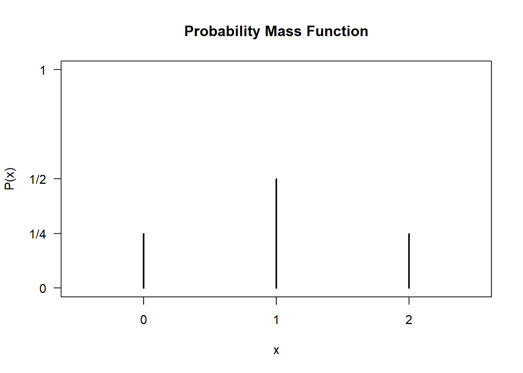

### Discrete Random Variables: Example

Let a chip be taken at random from a bowl that contains six white chips, three red chips, and one blue chip. Let the random variable $X = 1$ if the outcome is a white chip, let $X = 5$ if the outcome is a red chip, and let $X = 10$ if the outcome is a blue chip.

1. Find the pmf of X.
2. Graph the pmf as a line graph.

| $x$ | 1 | 5 | 10 |
| --- | --- | --- | --- |
| $P(x)$ | $\frac{3}{5}$ | $\frac{3}{10}$ | $\frac{1}{10}$ |

### Discrete Random Variables: Exercise

A tech company manufactures high-end smartphones. Before shipping, an automated inspector checks batches of 4 phones for screen defects. Let $X$ be the discrete random variable representing the number of defective phones found in a randomly selected batch of 4.Based on historical data, the probability mass function (PMF) $P(X = x)$ is given as follows:

| $x$ (Defects) | 0 | 1 | 2 | 3 | 4 |
| --- | --- | --- | --- | --- | --- |
| P(X=x)$ | 0.70 | 0.18 | 0.08 | k | 0.01 |

1. Find the value of $k$ to complete the PMF.
2. What is the probability that a batch has at least 2 defective phones?
3. What is the probability that a batch has fewer than 3 defective phones?

### Discrete Random Variables: Exercise

A ride-hailing driver operates in a busy downtown district. Let $Y$ be the discrete random variable representing the number of passenger ride requests the driver receives during a 15-minute period.

The PMF of $Y$ is estimated as:
$$P(Y = y) = \begin{cases} 0.15 &
\text{if } y = 0 \\ 0.40 & \text{if } y = 1 \\ 0.30 & \text{if }
y = 2 \\ 0.15 & \text{if } y = 3 \\ 0 & \text{otherwise}
\end{cases}$$
Verify that this function satisfies the two fundamental properties of a valid PMF.

- Non-negativity: All probabilities for each values that $Y$ can take are all greater than 0
- Sum of the probabiility is equal to 1

$$0.15 + 0.40 + 0.30 + 0.15 + 0 =
1$$

### Continuous Random Variables

Recall: For observations such as lengths of time, weight of an object, height of a person

- takes the range $R_X$ as a continuous sample space, and
- $X$ is called a continuous random variable.
- Here it is no longer appropriate to assign probabilities to individual values, because typically $P(X = x) = 0$.

### Continuous Random Variables

A continuous random variable has a non-negative probability density function (p.d.f.) $f(x)$ for all $x \in (-\infty, \infty)$ such that the probability of $X$ falling in a set $B$ is $P(X \in B) = \int_B f(x) dx$.

The p.d.f. $f(x)$ satisfies:

- $f(x) > 0$ for $x \in S$ .
- $\int_{-\infty}^{\infty} f(x) dx = 1$ .
- $P(a < x < b) = \int_a^b f(x) dx$ .
- Note: If $a=b$, then $P(x=a) = \int_a^a f(x) dx = 0$.

### Continuous Random Variables: Example

Suppose that $X$ is a continuous random variable whose probability density function is given by

$$\begin{align}
f(x) =
\begin{cases}
C(4x - 2x^2) & 0 < x < 2 \\
0 & \text{otherwise}
\end{cases}
\end{align}$$

1. What is the value of $C$?
2. Find $P(X>1)$

### Continuous Random Variables: Exercise

**Probability distribution for a continuous random variable**

The amount of time in hours that a computer functions before breaking down is a continuous random variable with probability density function given by

$$f(x) = \begin{cases} \lambda e^{-x/100}
& x \ge 0 \\ 0 & x < 0 \end{cases}$$

What is the probability that

1. A computer will function between 50 and 150 hours before breaking down?
2. It will function for fewer than 100 hours.

## Cumulative Distribution Function (CDF)

The CDF of a random variable $X$, denoted by $F(x)$, is defined as

$$\begin{align}
F(x) & = P(X \leq x) & \text{for all} \ x \\
F(x) &=\begin{cases}
\sum_{t \leq x} P(t) & \text{if } \qquad x \text{is discrete} \\
\int_{-\infty}^x f(t) dt & \text{if } \qquad x \text{is continuous}
\end{cases}
\end{align}$$

**Properties of a CDF include:**

- $\lim_{x \to -\infty} F(x) = 0$
- $\lim_{x \to \infty} F(x) = 1$
- $F(x)$ is a non-decreasing function of $x$
- $F(x)$ is right continuous

### Cumulative Distribution Function (CDF): Example (Discrete Case)

X has a p.m.f given by

| $x$ | 1 | 2 | 3 | 4 |
| --- | --- | --- | --- | --- |
| $P(x)$ | $\frac{1}{4}$ | $\frac{1}{2}$ | $\frac{1}{8}$ | $\frac{1}{8}$ |

Hence, the CDF are

$$\begin{align}
F(x) &=\begin{cases}
0 & x < 1 \\
\frac{1}{4} & 1 \le x < 2 \\
\frac{3}{4} & 2 \le x < 3 \\
\frac{7}{8} & 3 \le x le 4 \\
1 & 4 \le 4
\end{cases}
\end{align}$$

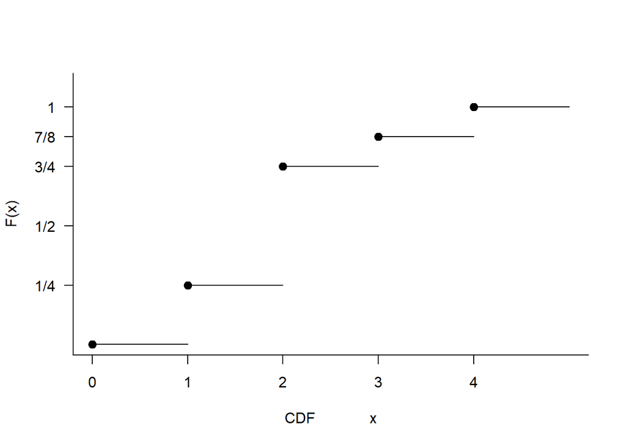

### Cumulative Distribution Function (CDF): Exercise (Discrete Case)

A batch of 15 items contains 6 defective ones. A random sample of 5 is chosen. Let $X$ be the number of defective items in the sample. Find the probability function and cumulative distribution function for $X$.

(Note: This is an extension of Example is Slide 2)

### Cumulative Distribution Function (CDF): Example (Continuous Case)

Let $X \in \mathbb{R}$ with PDF as

$$\begin{align}
f(x) =
\begin{cases}
0 & -\infty < x < 0 \\
\frac{1}{20} \exp \left(-\frac{x}{20}\right) & 0 \le < \infty
\end{cases}
\end{align}$$

**Derive** the CDF of $X$.

**Solution**
$$\begin{align}
F(x) &= \int_{-\infty}^{0} f(t) \ dt \\
&= \int_{0}^{x} \frac{1}{20} \exp \left(-\frac{x}{20}\right) \ dt
\\
&= \left[-\frac{x}{20}\right]_{0}^{x} = 1 - \exp
\left(-\frac{x}{2-}\right)
\end{align}$$

Check: the derivative of $F(x)$ must equal to $f(x)$

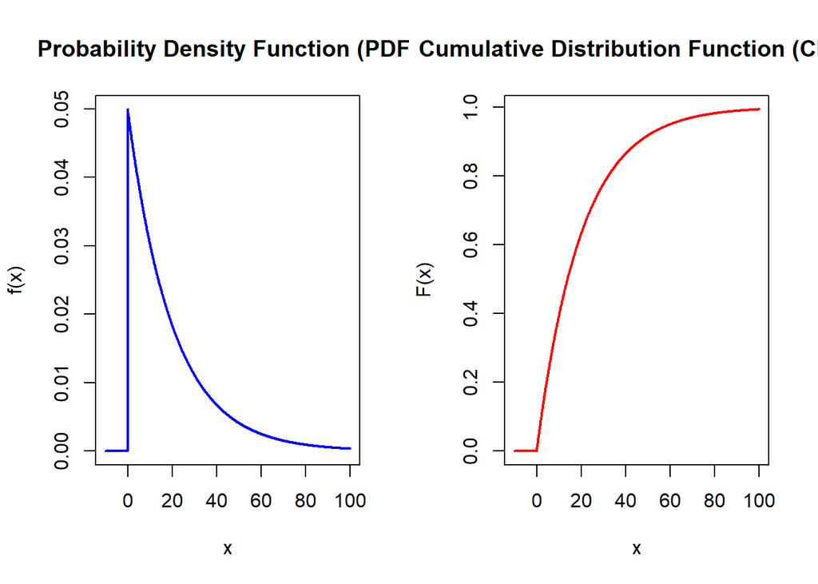

### Cumulative Distribution Function (CDF): Exercise (Continuous Case)

The random variable X has probability density function given by

$$\begin{align}
f(x) =
\begin{cases}
\frac{k}{(1 + x)^{4}} & \text{for} \ x \ge 0 \\
0 & \text{for} \ x \le 0
\end{cases}
\end{align}$$

For some positive constant $k$. Find the value of $k$, the distribution function $F(x)$ and the probabilities $P(X \le 1)$, $P(X > 1)$ and $P(1 \le X \le 2)$.

### Relationship between CDF, F(X) and PMF or PDF

| Transformation | Variable Type | Formula |
| --- | --- | --- |
| **F(x) $\rightarrow$ p.m.f, p.d.f** | If discrete | $P(x = a) = F(a) - F(a^-)$ |
|  | If continuous | $f(x) = \frac{dF(x)}{dx} = F'(x)$ |
| **p.m.f, p.d.f $\rightarrow$ F(x)** | If discrete | $F(x) = \sum P(x)$ |
|  | If continuous | $F(x) = \int_{-\infty}^{x} f(x)dx$ |

## Expected Values, Variance, and Moments

- Expected values
- Variance & Standard Deviation
- Method of Moments

### Expected Values

The **expected value** or **mean**, denoted by $E(X)$ or $\mu$, is the average of the outcomes

#### Expected Values: Example (Discrete)

Let $X$ equal number of spot on the side facing upwards after a six-sided die (one of pair of dice) is cast at a random. If everything is fair about this experiment, a reasonable probability model is given by the P.M.$F$.

$$f(x) = P(X = x) = \frac{1}{6}$$
where $x = 1, \ldots, 6$.

**Find** the expected value of the distribution of $X$.

$X$ is the number of spot on the side facing upwards after a six-sided die. To find the expected value,

$$\begin{align}
E[X] &= \sum x f(x) = \sum_{1}^{6} x \frac{1}{6}\\
&= \left(1 + 2 + 3 + 4 + 5 + 6 \right)\frac{1}{6} \\
&= \frac{7}{2} = 3.5
\end{align}$$

#### Expected Values: Example

Given that $X$ is the number of spot on the side facing upwards after a six-sided die.

Let $Y$ be the squared of number of spot on the side facing upwards after a six-sided die with the P.M.F of

$$\begin{align}
g(y) = P(Y = y) = \frac{1}{6}
\end{align}$$

where $y = 1, 4, 9, 16, 25, 36$. Find the expectation of $Y$.

**Solution**

- In this question, $Y$ is a function of $X$ where $Y = X^2$
- The value of $Y$ is no longer the value shown on the surface
- To find the expectation of $Y$, we must change the formula

  $$\begin{align}
  E[Y] &= \sum y f(y) = \sum_{1}^{6} y \frac{1}{6}\\
  &= \left( 1 + 4 + 9 + 16 + 25 + 36 \right)\frac{1}{6} \\
  &= \frac{91}{6} = 15.167 (3 \text{dp})
  \end{align}$$
- $E[Y]$ = $E[X^2]$ is the **second moment about the origin** with respect to variable $X$

#### Expected Values: Exercise (Discrete)

A batch of 15 items contains 6 defective ones. A random sample of 5 is chosen. Let $X$ be the number of defective items in the sample.

**Calculate** the expected value of the distribution of $X$.

#### Expected Values: Example (Continuous)

Let $X \in \mathbb{R}$ be a random variable with PDF of

$$\begin{align}
f(x) =
\begin{cases}
2x & \text{when} \qquad 0 \le x \le 1 \\
& \\
0 & \text{otherwise}
\end{cases}
\end{align}$$

**Calculate** the expected value of the distribution of $X$.

**Solution**

$$\begin{align}
E[X] &= \int_{0}^{1} x f(x) \\
&= \int_{0}^{1} 2x^2 \\
&= \left[\frac{2x^3}{3}\right]_{0}^{1} \\
&= \frac{2}{3}
\end{align}$$

### Expected Values: Properties

Let $a, c \in \mathbb{R}$ and $X$ and $Y$ be random variables with the same sample space.

- Expectation of a constant is a constant: $E(c) = c$.
- $E[aX] = aE[X]$.
- Linearity: $E[X] + c = E[X] + c$.
- Additivity: $E[X + Y ]= E[X] + E[Y]$.
- $|E(X)| \leq E(|X|)$.

### Functions of Random Variable

If $X$ is a random variable with CDF $F_{X}(x)$, the function of $X$ (e.g. $g(X)$) is also a random variable.

- We can rewrite the $g(X)$ as $Y = g(X)$
- Hence, $Y$ is a function of $X$

#### Functions of Random Variable: Expected Values

If $X$ is a random variable and $g(X)$ is a function of $X$. The expected value of $E[g(X)]$ is

$$\begin{align}
E[g(X)] =
\begin{cases}
\int g(x)f_{X}(x) \ dx & \text{if $X$ is continuous} \\
& \\
\sum g(x)f_{X}(x) = \sum g(x)P(X = x) & \text{if $X$ is discrete}
\end{cases}
\end{align}$$

#### Functions of Random Variable: Expected Values (Example)

Let $X$ be a continuous random variable representing the lifetime of a specific machine component (in years), with the P.D.F:

$$\begin{align}
f(x) =
\begin{cases}
\frac{1}{2} \exp \left(-\frac{x}{2}\right) & \text{for } x \ge 0 \\
0 & \text{otherwise}
\end{cases}
\end{align}$$

Suppose the maintenance cost (in RM) over the component’s lifetime is given by the function $g(X) = 50 + 10X^2$.

**Find** the expected maintenance cost, $E[g(X)]$.

**Solution:** By the linearity of expectation, we know that:
$$E[g(X)] = E[50 + 10X^2] = 50 +
10E[X^2]$$

First, find the second moment, $E[X^2]$:
$$\begin{align}
E[X^2] &= \int_{-\infty}^{\infty} x^2 f(x) dx \\
&= \int_{0}^{\infty} x^2 \left( \frac{1}{2} \exp
\left(-\frac{x}{2}\right) \right) dx
\end{align}$$

Using integration by parts (or the Gamma function property $\int_0^\infty x^n e^{-ax} dx = \frac{n!}{a^{n+1}}$):
$$\begin{align}
E[X^2] &= \frac{1}{2} \left( \frac{2!}{(1/2)^3} \right) \\
&= \frac{1}{2} (16) = 8
\end{align}$$

Now, substitute $E[X^2]$ back into the cost function:

$$\begin{align}
E[g(X)] &= 50 + 10(8) \\
&= 50 + 80 = 130
\end{align}$$

The expected maintenance cost is **RM 130**.

#### Functions of Random Variable: Expected Values Properties

Let $X$ be a random variable and $a, b, c \in \mathbb{R}$. Then, for any functions $g_{1}(x)$ and $g_{2}(x)$ whose expectations exists:

1. $E[ag_1(x) + bg_2(x) + c] = aEg_1(x) + bE[g_2(x)] + c$
2. If $g_1(x) \geq 0$ for all $x$, then $E[g_1(x)] \geq 0$
3. If $g_1(x) \geq g_2(x)$ for all $x$, then $E[g_1(x)] \geq E[g_2(x)]$
4. If $a \leq g_1(x) \leq b$ for all $x$, then $a \leq E[g_1(x)] \leq b$

#### Functions of Random Variable: Expected Values Example (Discrete)

If the journey length in kilometers is regarded as a random variable $X$, the linearity property
$$E[4 + 2X] = 4 + 2E[X]$$
just says that the average journey fare is RM4 plus RM2 times the average journey length. This is true whatever the distribution of $X$ is: the fare depends linearly on the journey length.

#### Functions of Random Variable: Expected Values Exercise (Continuous)

Uber charges a fare in RM of $y(X) = 4\sqrt{1 + X}$ for a journey of length X kilometers. Suppose the probability density function for $X$ is
$$f(x) = \frac{3}{(1 +
x)^{4}}$$
.

Find the mean fare.

### Variance and Standard Deviation

Variance is defined as
$$Var[X] =
E[(X-\mu)^2] = E[X^2] - \mu^2$$
. Standard deviation is $\sigma = \sqrt{Var(X)}$.

### Variance & Standard Deviation

The **variance**, denoted by $\sigma^{2}$.

- Continuous: $Var[X] = \int_{-\infty}^{\infty} x^{2} f(x) dx - (\int_{-\infty}^{\infty} x f(x) \ dx)^{2}$
- Discrete: $Var[X] = \sum x^2 f(x) - (\sum x f(x))^{2}$
  - provided that the integral or sum exists
- SD, $\sigma$, is just the square root of variance

#### Variance and Standard Deviation: Example (Discrete)

Let the P.M.F. of $X$ be defined by $f(x)=x/6$, where $x = 1, 2, 3$.The mean of $X$ is

$$\mu = E[X] = 1 \left(\frac{1}{6}\right)
+ 2 \left(\frac{2}{6}\right) + 3 \left(\frac{3}{6}\right) =
\frac{7}{3}$$
**Find** the variance and standard deviation of $X$.

**Solution:** Let $X = 1, 2, 3$ with the P.M.F of $f(x)=x/6$

$$\begin{align}
Var[X] =& E[(X-\mu)^2] = E[X^2] - \mu^2 \\
=& E[X^2] - \frac{7}{3}
\end{align}$$

The second order moment of $X$ is $E[X^{2}]$

#### Variance and Standard Deviation: Exercise (Discrete)

Compute the variance of the discrete distribution where

- $p(0) = 35/210$
- $p(1) = 105/210$
- $p(2) = 63/210$ and
- $p(3) = 7/210$.

### Variance and Standard Deviation

Show that $Var[a + bX] = b^2 Var[X]$.

#### Variance and Standard Deviation: Example (Continuous)

Let $X$ be a contious random variable with the P.D.F

$$\begin{align}
f(x) =
\begin{cases}
2x \qquad for \quad 0 \le x \le 1 \\
0 \qquad for \quad \text{otherwise} \\
\end{cases}
\end{align}$$

**Find** the expected value, standard deviation of $X$.

**Solution**

$$\begin{align}
E[X] &= \int x f(x) \\
&= \int_{0}^{1} x (2x) = \int_{1}^{1} 2x^2\\
&= \left[\frac{2}{3}x^{3}\right]_{0}^{1} \\
\end{align}$$

### Moments

- **Moments**: The $r$-th moment about the origin is $E(X^r)$. The $r$-th central moment is $E[(X-\mu)^r]$.
- Therefore, the $r$-th moment about the origin of a random variable is the expected value or $X^{r}$

$$\begin{align}
\mu_{r}^{'} = E[X^r] =
\begin{cases}
\sum_{x} x^r f(x) \\
& \\
\int x^r f(x) \\
\end{cases}
\end{align}$$

- The first moment is the mean, i.e. $E[X]$

### Central Moments

- The $r$-th moment about the **mean** of a random variable $X$, is the expected value of $(x - \mu_{x})^{r}$

$$\mu_{r} = E[(x - \mu_{x})^{r}] =
\begin{cases}
\sum_{x} (x - \mu_{X})^{r} f(x) \\
& \\
\int (x - \mu_{X})^{r} f(x) \\
\end{cases}$$

- The $r$-th moment about the mean of $X$ is called **$r$-th central moment of X**
- Note that

$$\mu_{1} = E[(x - \mu_{x})^{r}] =
0$$
$$\mu_{2} = E[(x - \mu_{x})^{2}] =
Var[X]$$

#### Exercise

The continuous random variable $X$ has distribution function given by

$$\begin{align}
f(x) =
\begin{cases}
x^3 & \text{when} \qquad 0 \le x \le 1 \\
& \\
0 & \text{when} \qquad x \le 0 \\
& \\
1 & \text{when} \qquad x \ge 0
\end{cases}
\end{align}$$

Find the probability density function of $X$, and also its mean and variance.

$$P(C \cup G \cup L) = P(C) + P(G) + P(L)
- P(C \cap G) - P(C \cap L) - P(G \cap L) + P(C \cap G \cap L)$$
$$P(C \cup G \cup L) = 0.470 + 0.334 + 0.346
- 0.119 - 0.151 - 0.104 + 0.048 = 0.824$$

### Solution

1. By the formula of combination,

$${n \choose r} =
\frac{n!}{r!(n-r)!}$$

We need to show that ${n \choose (n-r)} = \frac{n!}{r!(n-r)!}$.

$$\begin{align}
{n \choose (n-r)} =& \frac{n!}{(n-r)! r!} \\
=& \frac{n!}{(n-r)! (n-n( -r))!} \\
=& \frac{n!}{(n-r)! r!}
\end{align}$$

Since, multiplication is commutative,
$$\frac{n!}{(n-r)!r!} =
\frac{n!}{r!(n-r)!}$$
$$\therefore {n
\choose r} = \frac{n!}{r!(n-r)!} = {n \choose (n-r)}$$
2. Let $S$: The combination of two numbers shown on the dice.

- Let $A$: One of the die is 5 ($10$)
- Let $B$: Both dice cannot be the same number ($30$)

| (1, 1) | (1, 2) | (1, 3) | (1, 4) | (1, 5) | (1, 6) |
| --- | --- | --- | --- | --- | --- |
| (2, 1) | (2, 2) | (2, 3) | (2, 4) | (2, 5) | (2, 6) |
| (3, 1) | (3, 2) | (3, 3) | (3, 4) | (3, 5) | (3, 6) |
| (4, 1) | (4, 2) | (4, 3) | (4, 4) | (4, 5) | (4, 6) |
| (5, 1) | (5, 2) | (5, 3) | (5, 4) | (5, 5) | (5, 6) |
| (6, 1) | (6, 2) | (6, 3) | (6, 4) | (6, 5) | (6, 6) |

The probability of one of the die is 5 given that both dice cannot be the same number is

$$\begin{align}
P(A \mid B) =& \frac{A \cap B}{B} \\
=&\frac{10}{30} = \frac{1}{3}
\end{align}$$

3. Let
- $P(S)$: Overall probability of survival = 0.97
- $P(C)$: Probability of a C-section = 0.15
- $P(C')$: Probability of no C-section = 1 - 0.15 = 0.85
- $P(S\vert{}C)$: Probability of survival given a C-section = 0.96
- $P(S\vert{}C')$: Probability of survival given no C-section = ?

[interactive chart not shown]

$$\begin{align}
P(S) =& P(S\vert{}C)P(C) + P(S\vert{}C')P(C') \\
0.97 =& (0.96 \times 0.15) + (P(S\vert{}C') \times 0.85) \\
0.97 =& 0.144 + 0.85 \cdot P(S\vert{}C') \\
P(S\vert{}C') =& \frac{0.826}{0.85} = 0.97176.
\end{align}$$

The probability that the baby survives is approximately 97.18%

(assuming gender has only male and female)

1. The conditional probability that the student is male (i.e. Female), given that the student is majoring in Mathematics, $P(F' \mid M)$

$$\begin{align}
P(F' \mid M) =& \frac{P(F' \cap M)}{P(M)}
\end{align}$$

The probability joint probability of Male (F’) and Mathematics is

2. The conditional probability that the student is majoring in Mathematics given that the student is male, $P(M \mid F')$

$$\begin{align}
P(M \mid F') =& 0.05
\end{align}$$

[interactive chart not shown]

5. Let
- $P(S)$: The probability that the client posts a Story = 0.7
- $P(R)$: The probability that the client posts a Reel = 0.3
- $P(V \mid S)$: The probability that the client posts is viral given that the post is a Story = 0.2
- $P(V \mid R)$: The probability that the client posts is viral given that the post is a Reel = 0.6
1. Students should draw a tree with first branches $Story (0.7)$ and $Reel (0.3)$. The Story branch splits into $Viral (0.2)$ and $Not Viral (0.8)$. The Reel branch splits into $Viral (0.6)$ and $Not Viral (0.4)$

[interactive chart not shown]

2. Using the Law of Total Probability:
   $$\begin{align}
   P(V) &= P(S)P(V|S) + P(R)P(V|R) \\
   P(V) &= (0.2 \times 0.7) + (0.6 \times 0.3) \\
   P(V) &= 0.32 \ (2 \text{dp})
   \end{align}$$
3. To find the conditional probability that it was a Reel given that it goes Viral

We need $P(R|V)$:
$$\begin{align}
P(R|V) &= \frac{P(R \cap V)}{P(V)} \\
P(R|V) &= \frac{P(R)P(V|R)}{0.32} \\
&= \frac{0.3 \times 0.6}{0.32} \\
P(R|V) &= 0.5625 \ (\text{3 dp})
\end{align}$$

6. Let
- D: Drawing a diamond
- H: Drawing a heart
- S: Drawing a spade
- C: Drawing a club

$$\begin{align}
P(C \cap D \cap S \cap H) =& P(C) P(D \mid C) P(S \mid (D \cap C))
P(H \mid (C \cap D \cap S)) \\
=& \frac{13}{52} \frac{13}{51} \frac{13}{50} \frac{13}{49} =
\frac{2197}{499800} = 0.0044 (\text{4 dp})
\end{align}$$

7. Let
- $P(C)$: The probability that student uses Gemini for coding = 0.6
- $P(E)$: The probability that student uses Gemini for explanation = 0.4
- $P(A \mid C)$: The probability that the student achived A when using for Coding = 0.8
- $P(A \mid E)$: The probability that the student achived A when using for Explanation = 0.9
1. The tree diagram

[interactive chart not shown]

2. The total probability that a randomly selected student achieves an ‘A’ grade.

$$\begin{align}
P(A) =& P(A \mid C)P(C) + P(A \mid E)P(E) \\
P(A) =& (0.80 \times 0.60) + (0.90 \times 0.40) \\
P(A) =& 0.48 + 0.36 = 0.84
\end{align}$$

3. To be discussed in next lecture
8. Let
- $P(M)$: Probability a patient has the mutation = 0.02
- $P(H)$: Probability a patient is completely healthy = 0.98
- $P(V \mid M)$: Probability a patient is a heavy vaper, given they have the mutation = 0.90
- $P(V \mid H)$: Probability a patient is a heavy vaper, given they are healthy = 0.20

[interactive chart not shown]

To calculate the probability of a patient having throat mutation

$$\begin{align}
P(M \mid V) =& \frac{P(V \cap M)}{P(V) }\\
=& \frac{P(V \mid M) P(M)}{P(V)} \\
=& \frac{0.9 \times 0.02}{P(V)} \\
=& \frac{0.018}{P(V)}
\end{align}$$

To find the probability of a patient having heavy vaper, $P(V)$

$$\begin{align}
P(V) =& \frac{P(V \mid M) P(M) + P(V \mid H) P(H)}{P(V)} \\
=& 0.9 \times 0.02 + 0.98 \times 0.2 = 0.214
\end{align}$$

Hence, the probability of a patient having throat mutation

$$\begin{align}
P(M \mid V) =& \frac{P(V \cap M)}{P(V) }\\
=& \frac{P(V \mid M) P(M)}{P(V)} \\
=& \frac{0.018}{0.214}
=& 0.084 \ \text{3 dp}
\end{align}$$

The exact percentage chance that this specific patient has the throat mutation is 8.41%.

9. Let $C_{i}$ represent the door where the car is hidden, and $H_{j}$ represent the door that the host opens. You have already chosen Door 1.
- Initially, the car is equally likely to be behind any of the three doors:

$$P(C_{1})=P(C_{2})=P(C_{3})=\frac{1}{3}$$

- The host must open a door that you did not choose, and it must reveal a goat.
  - Case A: If the car is behind Door 1 $C_{1}$
  - The host can open either Door 2 or Door 3 with equal probability:

$$P(H_{3}\mid
C_{1})=\frac{1}{2}$$

- Case B: If the car is behind Door 2, $C_{2}$
- The host cannot open Door 1 (your choice) and cannot open Door 2 (the car). He is forced to open Door 3:

$$P(H_{3}\mid C_{2})=1$$

- Case C: If the car is behind Door 3, $C_{3}$
- The host cannot open Door 3 because the car is there. Therefore, the probability he opens Door 3 is zero:

$$P(H_{3}\mid C_{3})=0$$

Total Probability of the Host Opening Door 3

We calculate the overall probability that the host opens Door 3 ($P(H_3)$) by summing all possible scenarios:

$$\begin{align}
P(H_{3})=&[P(H_{3}\mid C_{1})\cdot P(C_{1})]+[P(H_{3}\mid
C_{2})\cdot P(C_{2})]+[P(H_{3}\mid C_{3})\cdot P(C_{3})] \\
P(H_{3})=&\left(\frac{1}{2}\cdot \frac{1}{3}\right)+\left(1\cdot
\frac{1}{3}\right)+\left(0\cdot \frac{1}{3}\right) \\
P(H_{3})=&\frac{1}{6}+\frac{1}{3}+0=\frac{3}{6}=\frac{1}{2}
\end{align}$$

Applying Bayes’ Theorem (The Posterior Probabilities)

Now we update our probabilities given the condition that the host has opened Door 3.

- Chance of winning if you Stick (Door 1):

$$\begin{align}
P(C_{1}\mid H_{3})=\frac{P(H_{3}\mid C_{1})\cdot
P(C_{1})}{P(H_{3})}=\frac{\frac{1}{2}\cdot
\frac{1}{3}}{\frac{1}{2}}=\frac{1}{3}\approx \mathbf{33.33\%}
\end{align}$$

- Chance of winning if you Switch (Door 2):

$$\begin{align}
P(C_{2}\mid H_{3})=\frac{P(H_{3}\mid C_{2})\cdot
P(C_{2})}{P(H_{3})}=\frac{1\cdot
\frac{1}{3}}{\frac{1}{2}}=\frac{2}{3}\approx \mathbf{66.67\%}
\end{align}$$

1. Given $P(A) = 0.4$, $P(B) = 0.5$, and $P(A \cap B) = 0.3$. CALCULATE the following:
   1. $P(A \cup B)$ [2 mark]
   2. $P(A \cap B')$ [2 mark]
   3. $P(A' \cup B')$ [2 mark]
2. Let $S:= \{1, 2, 3, 4, 5, 6, 7, 8, 9\}$, $A := \{1, 3, 5, 7, 9\}$, $B := \{1, 2, 4, 6, 7, 9\}$ and $C := \{s \in S : 2s \in B \}$. FIND the following:
   1. $A \cup B$ [2 mark]
   2. $(A \cup B)^{c}$ [2 mark]
   3. $C \notin A$ [2 mark]
3. Roll a fair six-sided die three times. Let
   - $A_1 = \{1 \text{ or } 2 \text{ on the first roll}\}$
   - $A_2 = \{3 \text{ or } 4 \text{ on the second roll}\}$
   - $A_3 = \{5 \text{ or } 6 \text{ on the third roll}\}$.

   It is given that
   - $P(A_i) = 1/3$ for $i = 1,2,3$;
   - $P(A_i \cap A_j) = (1/3)^2$ for $i \neq j$;
   - $P(A_1 \cap A_2 \cap A_3) = (1/3)^3$.
   1. Find $P(A_1 \cup A_2 \cup A_3)$.[2 mark]
   2. Show that $P(A_1 \cup A_2 \cup A_3) = 1 - \left(1 - \frac{1}{3}\right)^3$. [3 mark]

      (Hint: You need to **show** how to get the RHS from teh LHS)
4. How many four-letter code words are possible using the letters in IOWA if:
1. The letters may not be repeated?
2. The letters may be repeated?

[2 mark]

5. Suppose that Novak Djokovic and Roger Federer are playing a tennis match in which the first player to win three sets wins the match. Using D and F for the winning player of a set, in how many ways could this tennis match end?
6. A student uses Gemini to write a block of R code for their statistics assignment. The probability that the generated code runs perfectly without any errors on the first try is $0.82$. What is the probability that the code produces at least one error on the first try? [2 mark]
7. A user prompts Gemini to generate a meal plan. The response will feature exactly one primary protein source. The probability it features chicken ($C$) is $0.45$, and the probability it features tofu ($T$) is $0.20$. Since a single response cannot feature both as the primary source, these events are mutually exclusive. Calculate $P(C \cup T)$, the probability that the meal plan features either chicken or tofu. [1 mark]
8. A researcher asks Gemini to analyze a dataset. Let $A$ be the event that Gemini successfully reads the uploaded data, and let $B$ be the event that Gemini generates a correct visualization. The probability that Gemini reads the data is $P(A) = 0.90$. Given that it reads the data, the conditional probability that it generates a correct visualization is $P(B|A) = 0.70$. Find the probability that Gemini successfully reads the data **and** generates a correct visualization. [2 marks]
9. According to Current Population Reports, published by the U.S. Census Bureau, 51.6% of U.S. adults are female, 10.4% of U.S. adults are doctors, and 6.0% od U.S adults are female doctors. For a U.S adult selected at random, let
   - F = event the person is female
   - D = event the person is a doctor
1. Obtain $P(F)$, $P(D)$ and $P(F \cap D)$ [3 marks]
2. Determine (F or D)[1 marks]
3. Find the probability that a randomly selected adult is male. [2 marks]
10. There are three major GenAI website: ChatGPT, Gemini, and Claude. The national information indicates that 47.0% of the population subscribes to ChatGPT, 33.4% subscribes to Gemini, 34.6% subscribes to Claude, 11.9% subscribes to ChatGPT and Gemini, 15.1% subscribes to ChatGPT and Claude, 10.4% subscribes to Gemini and Claude, and 4.8% subscribes to all three. If a person is selected at random, determine the probability that it gets at least one of the three major GenAI. [3 marks]
1. Let $n \in \mathbb{N}$, and $r = 0, 1, 2, \dots, n$. Show that

$${n \choose r} = {n \choose
n-r}$$

2. Two fair dice are rolled. **Calculate** the conditional probability that at least one die lands on 5 given that the other die lands on different numbers? [3 mark]
3. From historical data, 97% babies survive during delivery. 15% are from cesarean section. When a C-section is performed, the baby survives 96% of the time. If a randomly chosen pregnant woman does not have a section, **what** is the probability the baby survive? [3 mark]
4. Forty-eight percent (48%) of the students of a certain university are males. Five percent (5%) of the students of this university are majoring in Mathematics. Five percent (5%) of the male students are majoring in Mathematics. If a student is selected at random, calculate the conditional probability that
   1. this student is male, given that the student is majoring in Mathematics
   2. this student is majoring in Mathematics, given the student is a male
5. An influencer marketing agency is analyzing a client’s Instagram account. Based on historical data, the client chooses to post either a **Story** or a **Reel**.
- The probability that the client posts a Story is 70% (0.7), and the probability they post a Reel is 30% (0.3).
- If they post a Story, the probability it goes “Viral” (gets over 10,000 views) is 20% (0.2).
- If they post a Reel, the probability it goes “Viral” is 60% (0.6).
  1. **Draw** a tree diagram to represent this scenario. Be sure to label all branches with their respective events and probabilities.
  2. **Calculate** the probability that a randomly selected post goes Viral.
  3. If you observe that a post has gone Viral, evalaute the conditional probability that it was a Reel?
6. You have a standard, shuffled deck of 52 cards. The cards are divided equally into four suits (four distinct events): Hearts, Diamonds, Clubs, and Spades (13 of each). You draw 4 cards in a row from the top of the deck, without replacing them. What is the probability of drawing exactly one of each suit in this specific order: Heart, Spade, Diamond, Club?
7. A university tracks how students use Gemini for their Probability and Statistics assignments. They find that 60% of students use Gemini primarily for coding help in R ($C$), while 40% use it primarily for conceptual explanations ($E$). (Level 5)

   At the end of the semester, 80% of the students who used it for coding achieved an ‘A’ grade ($A$), whereas 90% of those who used it for conceptual explanations achieved an ‘A’ grade.
   1. **Draw** a tree diagram to represent this scenario. [2 marks]
   2. **Calculate** the total probability that a randomly selected student achieves an ‘A’ grade. [2 marks]
   3. If a randomly selected student achieved an ‘A’ grade, use Bayes’ Theorem to **find** the probability that they used Gemini primarily for coding help. [3 marks]
8. You are looking at the relationship between heavy vaping and a specific, rare throat mutation that is a known precursor to cancer.Because the clinic sees a general population of young adults, the mutation is still relatively rare overall:
   - Only 2% of all patients who walk through the doors actually have this mutation.
   - The other 98% of patients have completely healthy throat tissue.

   You then look at the vaping habits of these patients:Vaping is heavily linked to the mutation.
   - If a patient has the mutation, there is a 90% chance they are a heavy vaper.
   - However, vaping is also just a common habit. If a patient is perfectly healthy, there is still a 20% chance they are a heavy vaper.

   A nurse hands you the intake file for a brand new patient in the waiting room. You haven’t seen their test results, but you see one checked box: The patient is a heavy vaper. Based on conditional probability, **calculate** is the exact percentage chance that this specific patient has the throat mutation?
9. You are a contestant on a game show. The host stands in front of three closed doors: Door 1, Door 2, and Door 3. Behind one of the doors is a brand new sports car. Behind the other two doors are goats. The host asks you to pick a door. You choose Door 1.

   The host knows exactly what is behind every door. After you make your pick, the host must open one of the two remaining doors that you did not pick, and he must always reveal a goat.

   The host walks over and opens Door 3. A goat is sitting behind it. He then turns to you and asks: “Do you want to stick with your original choice (Door 1), or do you want to switch to the other closed door (Door 2)?”

   Based on conditional probability, what are your exact percentage chances of winning the car if you stick with Door 1, versus if you switch to Door 2?
1. A discrete random variable $X$ has range $N$ and distribution function

   $$\begin{align}
   F(x) = \frac{x}{x + 1} \qquad \text{for} \ x = 1, 2, 3, \ldots
   \end{align}$$

   Find the corresponding probability function $f(x)$ and the probability $P(8 \le X \le 15)$.
2. A continuous random variable $X$ has range $\mathbb{R}^{+}$ and distribution function

   $$\begin{align}
   F(x) =
   \begin{cases}
   0 \ \text{for} \ x \le 0 \\
   \frac{x}{x + 1} \ \text{for} \ x \ge 0 \\
   \end{cases}
   \end{align}$$

   Find the corresponding probability density function $f(x)$ and the probability $P(8 \le X \le 15)$.
3. The continuous random variable $X$ has probability density function

$$\begin{align}
F(x) =
\begin{cases}
kx\exp\left(-\frac{x^2}{2}\right) \ \text{for} \ x \ge 0 \\
0 \ \text{for} \ x \le 0 \\
\end{cases}
\end{align}$$
where $k$ is a positive constant.

1. Find the value of $k$.
2. Find the distribution function (CDF) of $X$.
3. Evaluate $P(1 \le X \le 2)$.
4. Find the mean and variance of $X$.
5. Evaluate $E[\frac{1}{X}]$

You may use the standard fact that

$$\int_{0}^{\infty}
\exp\left(-\frac{x^2}{2}\right) = \sqrt{\frac{\pi}{2}}$$

4. Let $\lambda$ be a fixed positive constant, and define the function $f(x)$ by $f(x) = \frac{1}{2}\lambda e^{-\lambda x}$ if $x \ge 0$ and $f(x) = \frac{1}{2}\lambda e^{\lambda x}$ if $x < 0$.
1. Verify that $f(x)$ is a pdf.
2. If $X$ is a random variable with pdf given by $f(x)$, find $P(X < t)$ for all $t$. Evaluate all integrals.
5. A local retail study at Central Market (Pasar Seni) in Kuala Lumpur found that the number of traditional Batik shirts, $X$, purchased by an international tourist in a single visit does not follow standard probability models like the Binomial or Poisson distributions.Instead, the behavior is modeled by a custom discrete probability mass function defined as:
   $$P(X = x) = \begin{cases} c(x^2 + 1) &
   \text{for } x = 0, 1, 2, 3 \\ 0 & \text{otherwise}
   \end{cases}$$
1. Determine the value of the constant $c$ that makes this a valid probability distribution.
2. Find the probability that a randomly selected tourist buys at least 2 Batik shirts.
3. Calculate the expected number of Batik shirts a tourist will purchase, $E[X]$.
4. Each Batik shirt costs RM 40, and the tourist also pays a fixed RM 5 fee for a premium reusable shopping bag. The total amount spent by a tourist, $Y$, is a function of the random variable $X$, given by $Y = 40X + 5$. Calculate the expected total amount spent, $E[Y]$, and the variance of the amount spent, $\text{Var}(Y)$.
7. During the dry season, the Klang Valley in Malaysia often experiences transboundary haze. Environmental researchers model the daily Air Pollutant Index (API) during this severe period using a scaled continuous random variable $X$, where $X = \text{API} / 100$. The probability density function of $X$ is given by:

$$f(x) = \begin{cases} \frac{1}{4}x &
\text{for } 1 \le x \le 3 \\ 0 & \text{otherwise}
\end{cases}$$
(Note: $X=1$ corresponds to an API of 100, and $X=3$ corresponds to an API of 300).

1. Verify that $f(x)$ is a valid probability density function.
2. The air quality is categorized as “Very Unhealthy” when the API exceeds 200. Calculate the probability that a randomly selected day during this season has a “Very Unhealthy” air quality level ($X > 2$).
3. The daily economic cost, $Y$ (in tens of thousands of RM), due to medical treatments and reduced productivity is a function of the scaled API, given by the linear relationship $Y = 10X - 5$. Calculate the expected daily economic cost, $E[Y]$, and the variance of the cost, $\text{Var}(Y)$.
6. During the lunch hour at a major bank branch in Kuala Lumpur, the number of customers, $X$, already waiting in the priority service queue when a new customer pulls a ticket does not follow standard queueing models. Instead, historical ticketing data shows that the number of waiting customers ($X \in \{0, 1, 2, 3, 4\}$) follows a custom discrete probability mass function heavily skewed towards longer queues:

$$P(X = x) = \frac{x + 1}{15} \quad
\text{for } x = 0, 1, 2, 3, 4$$
a. Determine the Cumulative Distribution Function (CDF), $F(x)$, for all possible values of $X$.

Solve for the following:

1. State the Probability Density Function (PDF) of $Y$, $f_Y(y)$.
2. Find the Cumulative Distribution Function (CDF) of $Y$, $F_Y(y)$.
3. Construct the Probability Density Function (PDF) of $Y$, $f_Y(y)$.
4. Calculate the expected travel time, $E[Y]$.
5. Calculate the variance of the travel time, $\text{Var}(Y)$.
6. A popular navigation app claims there is a greater than 50% chance the driver will arrive in under 1 hour and 20 minutes (1.33 hours). By calculating the exact probability $P(Y < 1.33)$, evaluate whether the app’s claim is mathematically justified.